# Discussion 8

Po

11/24/2020

# Logistics

[Piazza](https://piazza.com/uc_davis/fall2020/sta137/home)

# ARIMA

## Glacial Varve Series

Let’s plot the Glacial Varve Series. The log transform makes the variance stable over time. The 1st order differencing makes it look like stationary.

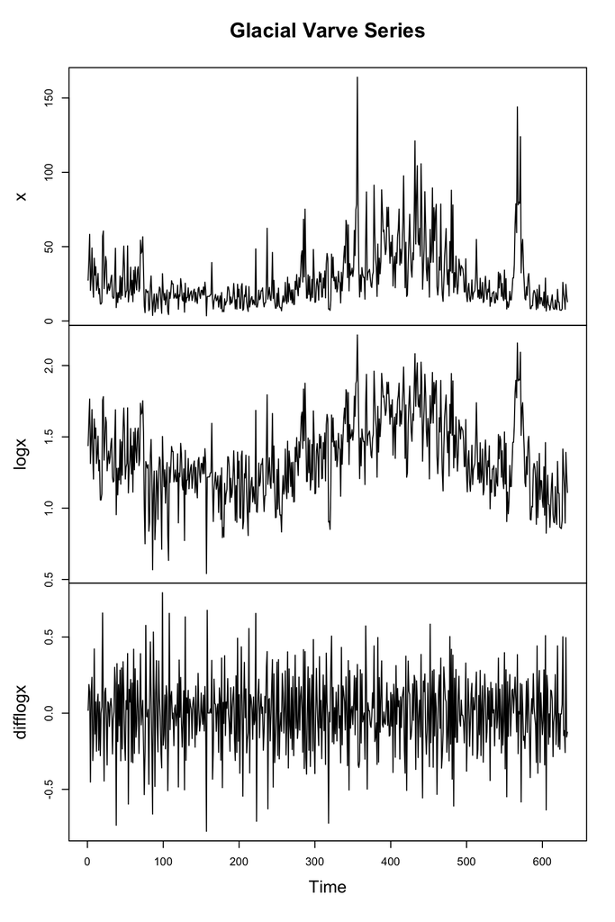

```r
gvss = ts(data.frame(
  x = astsa::varve[-1],
  logx = log10(astsa::varve)[-1],
  difflogx = diff(log10(astsa::varve))
))
title_string = "Glacial Varve Series"
plot(gvss, main = title_string)
```

Let’s fit ARIMA with $d = 1$ with. To determine the order, let’s plot ACF and PACF. ACF has lag 1 significant, while PACF has a longer decay. Our first guess is ARIMA(0,1,1).

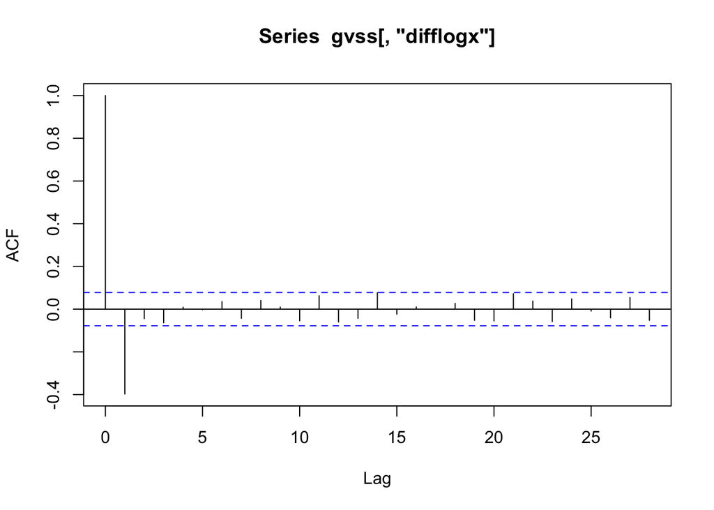

```r
acf(gvss[, "difflogx"])
```

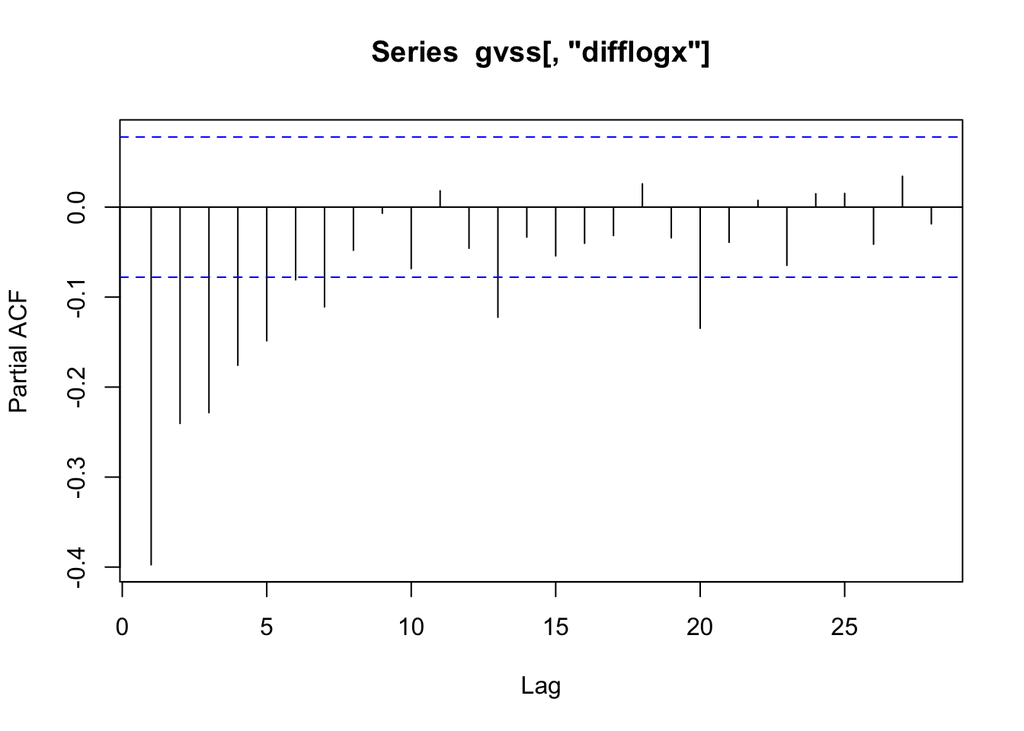

```r
pacf(gvss[, "difflogx"])
```

However, the residual of the ARIMA(0,1,1) fit still has non-zero autocorrelation.

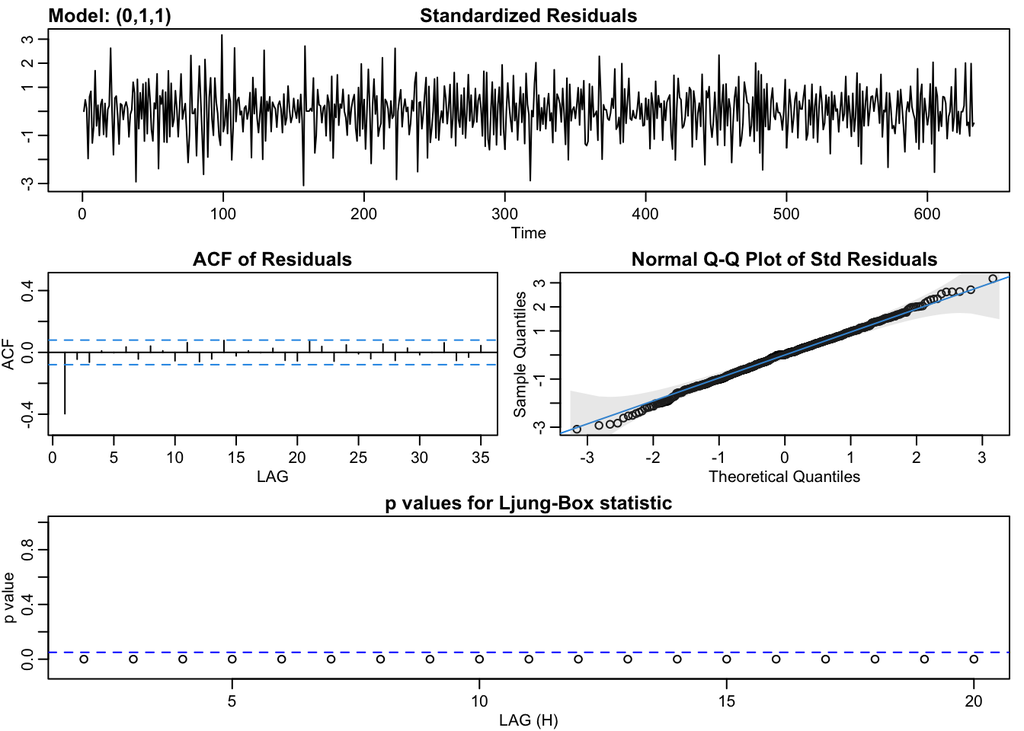

```
## $fit
##
## Call:
## stats::arima(x = xdata, order = c(p, d, q), seasonal = list(order = c(P, D,
##     Q), period = S), xreg = constant, transform.pars = trans, fixed = fixed,
##     optim.control = list(trace = trc, REPORT = 1, reltol = tol))
##
## Coefficients:
##          ma1  constant
##       -1.000     0e+00
## s.e.   0.004     1e-04
##
## sigma^2 estimated as 0.06266:  log likelihood = -24.66,  aic = 55.32
##
## $degrees_of_freedom
## [1] 630
##
## $ttable
##          Estimate    SE   t.value p.value
## ma1            -1 4e-03 -250.3137  0.0000
## constant        0 1e-04   -0.0396  0.9685
##
## $AIC
## [1] 0.08752984
##
## $AICc
## [1] 0.08756003
##
## $BIC
## [1] 0.108648
```

```r
astsa::sarima(gvss[, "difflogx"], 0, 1, 1)
```

Trying some others set of $(p,q)$, we find ARIMA(1,1,2) fit seems to have residual looking white…

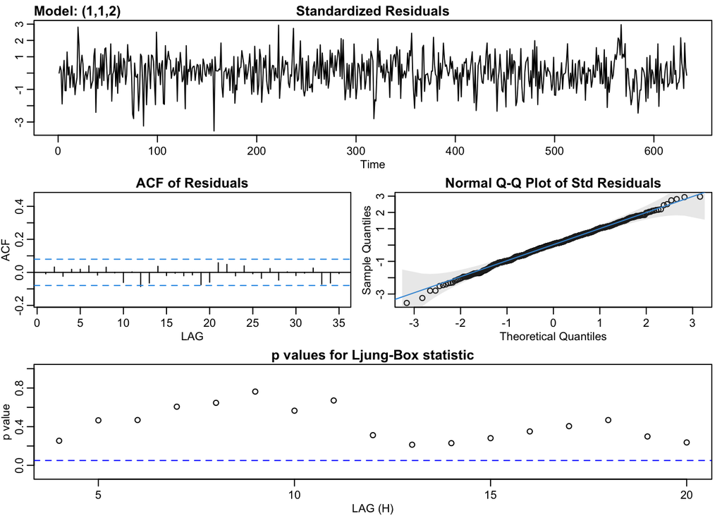

```
## $fit
##
## Call:
## stats::arima(x = xdata, order = c(p, d, q), seasonal = list(order = c(P, D,
##     Q), period = S), xreg = constant, transform.pars = trans, fixed = fixed,
##     optim.control = list(trace = trc, REPORT = 1, reltol = tol))
##
## Coefficients:
##          ar1      ma1     ma2  constant
##       0.2303  -1.8823  0.8823         0
## s.e.  0.0509   0.0309  0.0307         0
##
## sigma^2 estimated as 0.04314:  log likelihood = 90.89,  aic = -171.79
##
## $degrees_of_freedom
## [1] 628
##
## $ttable
##          Estimate     SE  t.value p.value
## ar1        0.2303 0.0509   4.5218  0.0000
## ma1       -1.8823 0.0309 -60.9701  0.0000
## ma2        0.8823 0.0307  28.7786  0.0000
## constant   0.0000 0.0000  -0.0516  0.9588
##
## $AIC
## [1] -0.2718163
##
## $AICc
## [1] -0.2717153
##
## $BIC
## [1] -0.2366194
```

```r
astsa::sarima(gvss[, "difflogx"], 1, 1, 2)
```

If you set (p,q) to be higher, you can still get residual looking white, for example, ARIMA(2,1,2). But it is not as good as ARIMA(1,1,2). Firstly, here we got some extra parameters. Secondly, now we have some fitted coefficients “not significant”. Thirdly, those AIC things doesn’t decrease.

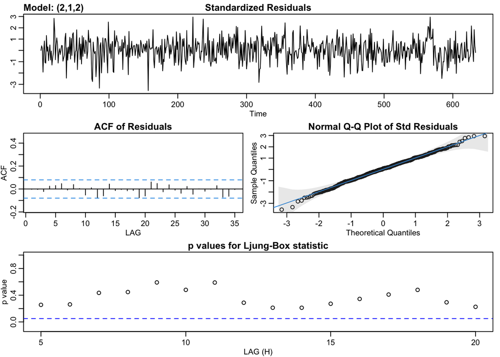

```
## $fit
##
## Call:
## stats::arima(x = xdata, order = c(p, d, q), seasonal = list(order = c(P, D,
##     Q), period = S), xreg = constant, transform.pars = trans, fixed = fixed,
##     optim.control = list(trace = trc, REPORT = 1, reltol = tol))
##
## Coefficients:
##          ar1     ar2      ma1     ma2  constant
##       0.2452  0.0495  -1.9031  0.9032         0
## s.e.  0.0483  0.0457   0.0298  0.0296         0
##
## sigma^2 estimated as 0.04309:  log likelihood = 91.32,  aic = -170.64
##
## $degrees_of_freedom
## [1] 627
##
## $ttable
##          Estimate     SE  t.value p.value
## ar1        0.2452 0.0483   5.0789  0.0000
## ar2        0.0495 0.0457   1.0828  0.2793
## ma1       -1.9031 0.0298 -63.9514  0.0000
## ma2        0.9032 0.0296  30.5245  0.0000
## constant   0.0000 0.0000  -0.0585  0.9533
##
## $AIC
## [1] -0.2700025
##
## $AICc
## [1] -0.2698508
##
## $BIC
## [1] -0.2277662
```

```r
astsa::sarima(gvss[, "difflogx"], 2, 1, 2)
```

## Moral of the story

We choose ARIMA(p, d, q) so that the residual looks white (stationary and zero autocorrelation, or maybe normal (normal+zero-correlation => independent!)), while the AIC, BIC things keep minimum.

# Regression with ARMA error

## Lynx–Hare Populations

Text book example 5.17

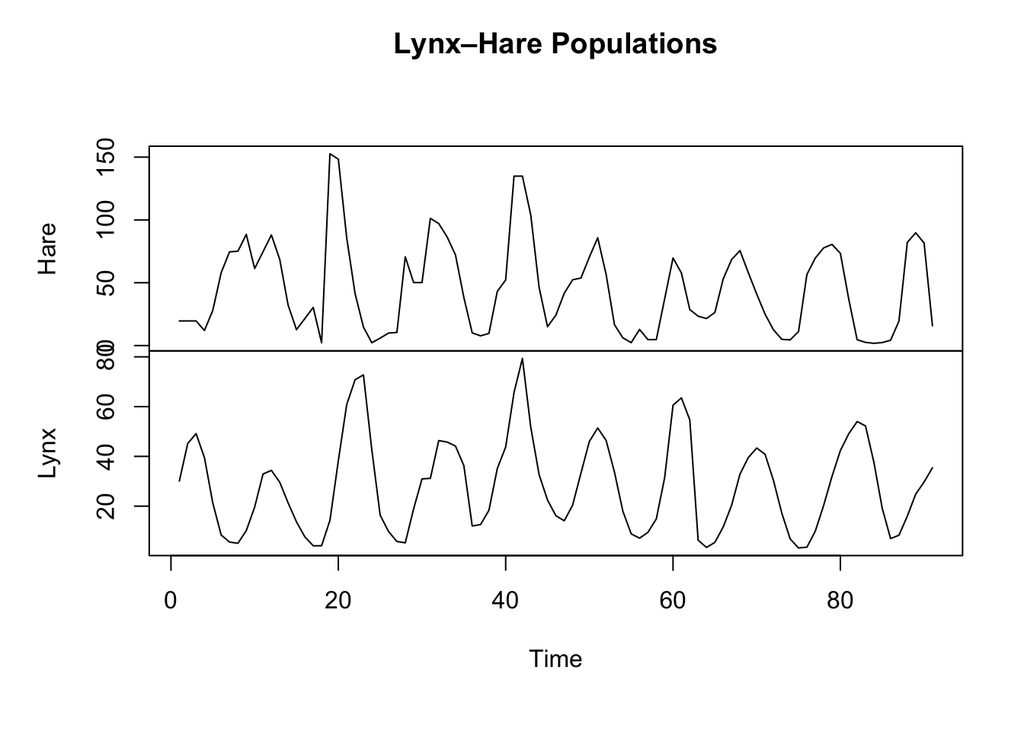

```r
library(astsa)
df = ts(data.frame(
  Hare = Hare,
  Lynx = Lynx
))
title_string = "Lynx–Hare Populations"
plot(df, main = title_string)
```

Hare lag 1 seems to be a good predictor for Lynx.

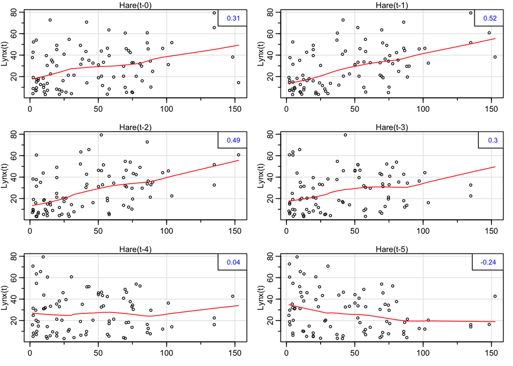

```r
library(zoo)
lag2.plot(Hare, Lynx, 5) # lead-lag relationship
```

Fit linear regression model

```r
pp = as.zoo(ts.intersect(Lynx, HareL1 = lag(Hare,-1)))
summary(reg <- lm(pp$Lynx~ pp$HareL1))
```

```
##
## Call:
## lm(formula = pp$Lynx ~ pp$HareL1)
##
## Residuals:
##     Min      1Q  Median      3Q     Max
## -31.107 -11.511  -2.193   7.579  45.632
##
## Coefficients:
##             Estimate Std. Error t value Pr(>|t|)
## (Intercept) 15.84712    2.75817   5.746 1.29e-07 ***
## pp$HareL1    0.27265    0.04727   5.768 1.17e-07 ***
## ---
## Signif. codes:  0 '***' 0.001 '**' 0.01 '*' 0.05 '.' 0.1 ' ' 1
##
## Residual standard error: 16.25 on 88 degrees of freedom
## Multiple R-squared:  0.2744, Adjusted R-squared:  0.2661
## F-statistic: 33.27 on 1 and 88 DF,  p-value: 1.172e-07
```

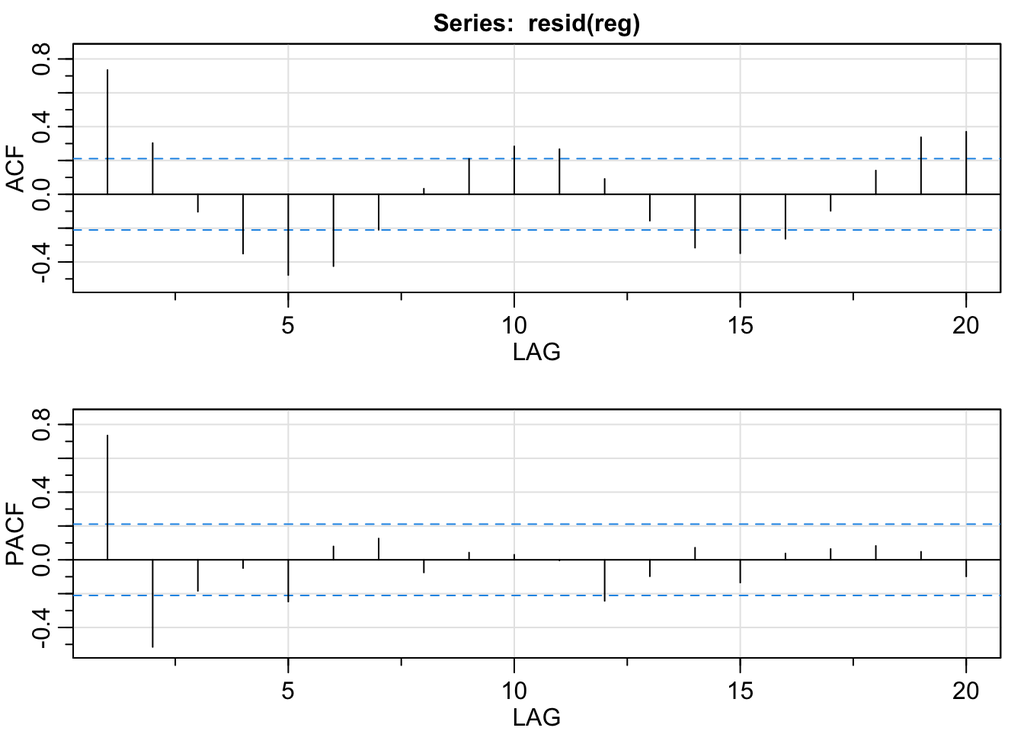

```
##      [,1]  [,2]  [,3]  [,4]  [,5]  [,6]  [,7]  [,8] [,9] [,10] [,11] [,12]
## ACF  0.73  0.30 -0.10 -0.35 -0.48 -0.43 -0.21  0.03 0.21  0.28  0.27  0.09
## PACF 0.73 -0.52 -0.18 -0.05 -0.25  0.08  0.13 -0.08 0.04  0.03  0.00 -0.24
##      [,13] [,14] [,15] [,16] [,17] [,18] [,19] [,20]
## ACF  -0.16 -0.32 -0.35 -0.26 -0.10  0.14  0.34  0.37
## PACF -0.10  0.07 -0.13  0.04  0.06  0.08  0.05 -0.10
```

```r
acf2(resid(reg))
```

Maybe an AR(2) model for the residual?

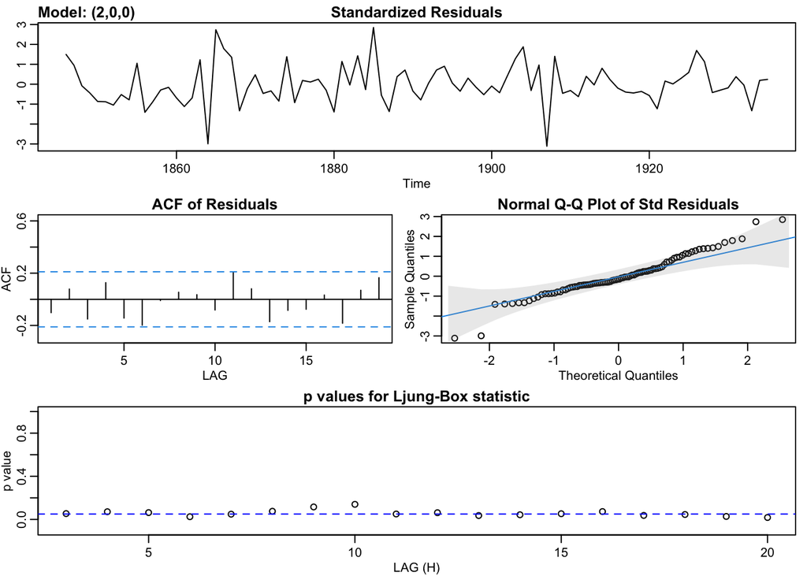

```
## $fit
##
## Call:
## stats::arima(x = xdata, order = c(p, d, q), seasonal = list(order = c(P, D,
##     Q), period = S), xreg = xmean, include.mean = FALSE, transform.pars = trans,
##     fixed = fixed, optim.control = list(trace = trc, REPORT = 1, reltol = tol))
##
## Coefficients:
##          ar1      ar2   xmean
##       1.1275  -0.5225  0.1064
## s.e.  0.0890   0.0901  2.4372
##
## sigma^2 estimated as 83.69:  log likelihood = -327.64,  aic = 663.29
##
## $degrees_of_freedom
## [1] 87
##
## $ttable
##       Estimate     SE t.value p.value
## ar1     1.1275 0.0890 12.6690  0.0000
## ar2    -0.5225 0.0901 -5.7985  0.0000
## xmean   0.1064 2.4372  0.0436  0.9653
##
## $AIC
## [1] 7.369852
##
## $AICc
## [1] 7.372953
##
## $BIC
## [1] 7.480955
```

```r
astsa::sarima(resid(reg), 2, 0, 0)
```

## Moral of the story

In STA108 Regression Analysis, we learned that the errors is assumed to be independent normal. Nevertheless, it is valid to fit linear regression when the errors are correlated. (Hopeful you will understand the rationale in mathematical statistics classes…)